# statisticl-inference-project

Abdelrahman Elsehaily

## Overview

This project from Statisticl Inference course on coursera, the goal is to investigate the exponential distribution in R and compare it with the Central Limit Theorem.

## 1.Simulation

Created one thousand loops, in each iteration creating a new sample and getting the mean only as we only interested in the distribution of the mean.

```r
lambda=0.2
sample_means=NULL
for (i in 1 : 1000) sample_means = c(sample_means, mean(rexp(40,rate =lambda)))
```

## 2.Sample Mean versus Theoretical Mean:

we wanna to check the mean of our samples means and see how it differs from the Theoretical Mean(Population Mean)

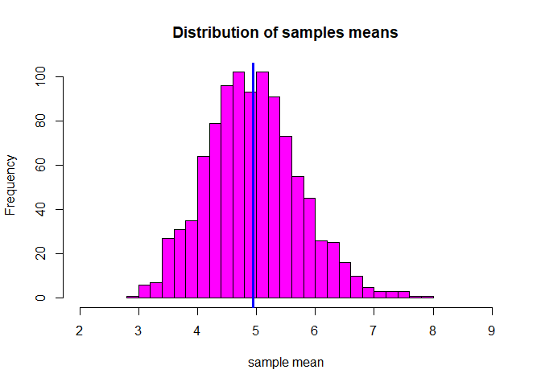

```r
hist(sample_means,breaks = 20,xlim = c(2,9),col = "magenta",xlab = "sample mean",main="Distribution of samples means")
abline(v=mean(sample_means),col="blue",lwd=3)
```

```r
print(paste("Sample Mean: ",mean(sample_means)))
```

```
## [1] "Sample Mean:  4.94459703254333"
```

```r
print(paste("Therortical Mean: ",1/lambda))
```

```
## [1] "Therortical Mean:  5"
```

The sample mean is approximately as the population mean as states in the Centeral Limit Theorm

## 3.Sample Variance versus Theoretical Variance:

we wanna to check the sample varience given our simulation and the theoritcal varience and also check the variance of the sampe given the CLT

```r
print(paste("Theoretical Variance: ",1/lambda))
```

[output not shown]

```r
print(paste("sample Variance from our simulation: ",sd(sample_means)))
```

[output not shown]

```r
print (paste("sample varience from CLT: ",(1/lambda/sqrt(40))))
```

[output not shown]

## 4.Distribution

now we wanna see difference between the distribution of a large collection of random exponentials and the distribution of a large collection of averages of 40 exponentials we will plot the density instead of the count of the numbers.

### The distribution of the random exponentials

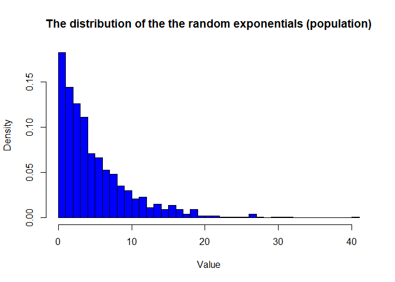

```r
hist(rexp(1000,rate=lambda),breaks = 50,col = "blue",xlab = "Value",freq = F,main="The distribution of the the random exponentials (population)")
```

### The distribution of the samples means

To show if the samples mean distribution follow normal distribution or not I plotted the curve of normal distribution with mean and veriance equal to the mean and veriance of the samles means.

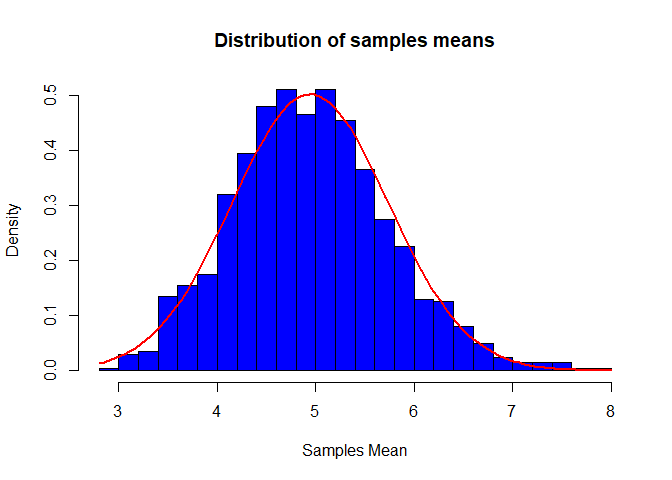

```r
hist(sample_means,breaks = 20,col = "blue",xlab = "Samples Mean",main="Distribution of samples means",freq=F)
curve(dnorm(x, mean=mean(sample_means), sd=sd(sample_means)), add=TRUE, col="red", lwd=2)
```